# Export von Kriegsmaterial aus der Schweiz

Vorprozessierung und Analyse

SRF Data, Timo Grossenbacher (timo.grossenbacher@srf.ch), Marie-Louise Timcke (marie.timcke@journocode.com)

Februar 2017

### Vorbemerkungen

Dieses Dokument beschreibt die Vorprozessierung und explorative Analyse des Datensatzes, der Grundlage der beiden auf srf.ch veröffentlichten Artikel [Schweizer Rüstungsexporte: Sind die fetten Jahre vorbei?](http://www.srf.ch/news/schweiz/schweizer-ruestungsexporte-sind-die-fetten-jahre-vorbei) und [Sieben Infografiken zu Waffen-Exporten aus der Schweiz](http://www.srf.ch/news/schweiz/sieben-infografiken-zu-waffen-exporten-aus-der-schweiz) ist.

SRF Data legt Wert darauf, dass die Datenvorprozessierung und -Analyse nachvollzogen und überprüft werden kann. SRF Data glaubt an das Prinzip offener Daten, aber auch offener und nachvollziehbarer Methoden. Zum anderen soll es Dritten ermöglicht werden, auf dieser Vorarbeit aufzubauen und damit weitere Auswertungen oder Applikationen zu generieren.

Die Vorprozessierung und Analyse wurde im Statistikprogramm R vorgenommen. Die Endprodukte des verwendeten Scripts sind:

- `output/export.csv`: Vollständiger, aggregierter Datensatz, der aus den einzelnen Jahresstatistiken des SECO geschaffen wird. Dieser Datensatz wird im folgenden Kapitel beschrieben.

### R-Script & Daten

Die Vorprozessierung und Analyse wurde im Statistikprogramm R vorgenommen. Das zugrunde liegende Script sowie die prozessierten Daten können unter [diesem Link](https://srfdata.github.io/2017-02-kriegsmaterial/rscript.zip) heruntergeladen werden. Durch Ausführen von `main.Rmd` kann der hier beschriebene Prozess nachvollzogen und der für den Artikel verwendete Datensatz generiert werden. Dabei werden Daten aus dem Ordner `input` eingelesen und Ergebnisse in den Ordner `output` geschrieben.

SRF Data verwendet das rddj-template von Timo Grossenbacher als Grundlage für seine R-Scripts. Entstehen bei der Ausführung dieses Scripts Probleme, kann es helfen, die Anleitung von rddj-template zu studieren.

Debug-Informationen: *This report was generated on 2018-12-07 17:19:22. R version: 3.3.3 on x86_64-pc-linux-gnu. For this report, CRAN packages as of 2017-06-01 were used.*

### GitHub

Der Code für die vorliegende Datenprozessierung ist auf https://github.com/srfdata/2017-02-kriegsmaterial zur freien Verwendung verfügbar.

### Lizenz

2017-02-kriegsmaterial von [SRF Data](https://github.com/srfdata/2017-02-kriegsmaterial) ist lizenziert unter einer [Creative Commons Namensnennung - Weitergabe unter gleichen Bedingungen 4.0 International Lizenz](http://creativecommons.org/licenses/by-sa/4.0/).

#### Weitere Projekte

Code & Daten von [SRF Data](http://srf.ch/data) sind unter http://srfdata.github.io verfügbar.

#### Haftungsausschluss

Die veröffentlichten Informationen sind sorgfältig zusammengestellt, erheben aber keinen Anspruch auf Aktualität, Vollständigkeit oder Richtigkeit. Es wird keine Haftung übernommen für Schäden, die durch die Verwendung dieses Scripts oder der daraus gezogenen Informationen entstehen. Dies gilt ebenfalls für Inhalte Dritter, die über dieses Angebot zugänglich sind.

### Datenbeschreibung `export.csv`

| Attribut | Typ | Beschreibung |
| --- | --- | --- |
| Land | String | Land, in das die Güter exportiert werden. |
| Jahr | Integer | Jahr, in dem die Güter exportiert wurden. |
| Kategorie | String | Kategorie der ausgeführten Güter, siehe unten. |
| Wert | Integer | Wert der Güter in Schweizer Franken. |

#### Originalquelle

Alle Originalstatistiken seit 2000 sind auf der Website des SECO abrufbar.

Es wurde jeweils die Datei “Ausfuhren nach Kategorie pro Endempfängerstaat” verwendet.

Vom SECO wurden SRF Data, wo vorhanden, Excel-Dateien zur Verfügung gestellt. Wo nicht, wurden die vorhandenen PDF-Dateien in einem mehrstufigen Prozess maschinenlesbar gemacht und darauf in die Ursprungsdatei `input/2000-2016.xlsx` überführt.

#### Was steht hinter den Kategoriekürzeln?

| Kürzel | Beschreibung |
| --- | --- |
| KM1 | Hand- und Faustfeuerwaffen jeglichen Kalibers |
| KM2 | Waffen jeglichen Kalibers (jedoch ohne Hand- und Faustfeuerwaffen soweit hievor in KM 1 erfasst) |
| KM3 | Munition für die in KM 1, 2 oder 12 erfassten Waffen |
| KM4 | Bomben, Torpedos, Raketen, Flugkörper |
| KM5 | Feuerleiteinrichtungen |
| KM6 | Panzer- und andere Landfahrzeuge |
| KM7 | Tränengase u.a. Reizstoffe |
| KM8 | Militärische Explosiv-, Brenn- und Treibstoffe |
| KM10 | Bemannte und unbemannte Luftfahrzeuge inkl. entsprechende Triebwerke |
| KM16 | Schmiedestücke, Gussstücke und andere unfertige Erzeugnisse |
| Andere | KM9, KM11-KM15, KM17-KM22, Kryogenische (Tieftemperatur-) und supraleitende Ausrüstung (KM20), ansonsten Software, Strahlenwaffen, Kriegsschiffe… |

### Vorbereitungen

```
## [1] "package package:rmarkdown detached"
```

### Packages definieren

```r
cat("
library(dplyr)
library(tidyr)
library(ggplot2)
library(readxl)
library(stringr)
library(scales)
library(grid)
library(rmarkdown)
library(reshape)",
file = "manifest.R")
```

### Packages installieren

```r
# if checkpoint is not yet installed, install it (for people using this
# system for the first time)
if (!require(checkpoint)) {
  if (!require(devtools)) {
    install.packages("devtools", repos = "http://cran.us.r-project.org")
    require(devtools)
  }
  devtools::install_github("RevolutionAnalytics/checkpoint",
                           ref = "v0.3.2", # could be adapted later,
                           # as of now (beginning of July 2017
                           # this is the current release on CRAN)
                           repos = "http://cran.us.r-project.org")
  require(checkpoint)
}
```

```
##
## checkpoint: Part of the Reproducible R Toolkit from Microsoft
## https://mran.microsoft.com/documents/rro/reproducibility/
```

```r
# nolint start
if (!dir.exists("~/.checkpoint")) {
  dir.create("~/.checkpoint")
}
# nolint end
# install packages for the specified CRAN snapshot date
checkpoint(snapshotDate = package_date,
           project = path_to_wd,
           verbose = T,
           scanForPackages = T,
           use.knitr = F,
           R.version = R_version)
```

```
## Scanning for packages used in this project
```

```
## rmarkdown files found and will not be parsed. Set use.knitr = TRUE
```

```
## - Discovered 11 packages
```

```
## All detected packages already installed
```

```
## checkpoint process complete
```

```r
rm(package_date)
```

### Packages laden

```r
source("manifest.R")
unlink("manifest.R")
```

### Vorprozessierung

#### Daten reinladen und typisieren

```r
# 2000 - 2016

# Alle Exceltabellen liegen aufsteigend in einer Arbeitsmappe, so dass sheet1 = 2000, sheet2 = 2001 usw
# lade alle sheets der Arbeitsmappe als data frames in eine Liste sheets
sheets <- list()
for(i in 1:17){
 sheets[[i]] <- read_excel("input/2000-2016.xlsx", sheet = i)
 k <- c(2000:2016)
 sheets[[i]]$Jahr <- k[i]
}
# Liste "sheets" enthält nun einzelne data frames, wobei sheets[[1]]= 2000, sheets[[2]]= 2001 usw.

# einzelne dataframes zu einem einzigen frame mergen und durch leere Spalten in den Ausgangsdaten erzeugte NA's durch Nullen ersetzen
export <- do.call(rbind.data.frame, sheets)
export[is.na(export)] <- 0
rm(sheets, i ,k)
```

#### Restrukturieren

```r
# # Daten kondensieren (breit nach lang)
export_restructured <- export %>%
  as.data.frame() %>%
  tidyr::gather(key = "variable", value = "value", 2:12)
rm(export)
```

#### Länder-Duplikate entfernen

Wie viele Länder gibt es?

```r
laender <- arrange(export_restructured, Land) # nach Ländernamen sortieren
unique(laender$Land) # vorkommende Ländernamen anzeigen: gibt es Duplikate
```

```
##   [1] "Aegypten"                       "Aegypten / Egypte"
##   [3] "Ägypten"                        "Algerien"
##   [5] "Andorra"                        "Antillen, Niederl."
##   [7] "Arab. Emirate / Emirats Arabes" "Arabische Emirate"
##   [9] "Argentinien"                    "Argentinien / Argentine"
##  [11] "Australien"                     "Australien / Australie"
##  [13] "Bahrain"                        "Bahrein"
##  [15] "Bahrein / Bahrein"              "Bangladesch"
##  [17] "Bangladesh"                     "Barbados"
##  [19] "Belgien"                        "Belgien / Belgique"
##  [21] "Belize"                         "Benin"
##  [23] "Benin / Bénin"                  "Benin /Benin"
##  [25] "Bermuda"                        "Bosnien"
##  [27] "Bosnien / Bosnie"               "Bosnien und Herzeg."
##  [29] "Botswana"                       "Botswana / Botswana"
```

[output cut: 103 more lines]

```r
length(unique(laender$Land)) # wie viele Länder gibt es insgesamt (mit Duplikaten)?
```

```
## [1] 235
```

Manuell umschreiben

```r
export_restructured$Land[export_restructured$Land == "Aegypten / Egypte"|export_restructured$Land == "Aegypten"] <- "Ägypten"
export_restructured$Land[export_restructured$Land == "Andorra "] <- "Andorra"
export_restructured$Land[export_restructured$Land == "Arab. Emirate / Emirats Arabes"|export_restructured$Land == "Arabische Emirate"] <- "Vereinigte Arabische Emirate"
export_restructured$Land[export_restructured$Land == "Argentinien / Argentine"] <- "Argentinien"
export_restructured$Land[export_restructured$Land == "Australien / Australie"] <- "Australien"
export_restructured$Land[export_restructured$Land == "Bahrein"|export_restructured$Land =="Bahrein / Bahrein"] <- "Bahrain"
export_restructured$Land[export_restructured$Land == "Belgien "|export_restructured$Land =="Belgien / Belgique"] <- "Belgien"
export_restructured$Land[export_restructured$Land == "Benin "|export_restructured$Land == "Benin /Benin"|export_restructured$Land == "Benin / Bénin"] <- "Benin"
export_restructured$Land[export_restructured$Land == "Bosnien / Bosnie"|export_restructured$Land == "Bosnien"|export_restructured$Land == "Bosnien und Herzeg."] <- "Bosnien-Herzegowina"
export_restructured$Land[export_restructured$Land == "Botswana / Botswana"|export_restructured$Land == "Botwana"] <- "Botswana"
export_restructured$Land[export_restructured$Land == "Brasilien / Brésil"] <- "Brasilien"
export_restructured$Land[export_restructured$Land == "Bangladesh"] <- "Bangladesch"
export_restructured$Land[export_restructured$Land == "Brunei /Brunei"|export_restructured$Land == "Brunel"] <- "Brunei"
export_restructured$Land[export_restructured$Land == "Bulgarien / Bulgaarie"|export_restructured$Land == "Bulgarien / Bulgarie"] <- "Bulgarien"
export_restructured$Land[export_restructured$Land == "Burkina Fasso / Burkina Faso"|export_restructured$Land == "Burkin Fasso"|export_restructured$Land == "Burkina Fasso"] <- "Burkina Faso"
export_restructured$Land[export_restructured$Land == "Buthan / Bouthan"|export_restructured$Land =="Buthan"] <- "Bhutan"
export_restructured$Land[export_restructured$Land == "Chile / Chili"] <- "Chile"
export_restructured$Land[export_restructured$Land == "Costa Rica / Costa Rica"] <- "Costa Rica"
export_restructured$Land[export_restructured$Land == "Dänemark / Danemark"] <- "Dänemark"
export_restructured$Land[export_restructured$Land == "Deutschland / Allemagne"] <- "Deutschland"
export_restructured$Land[export_restructured$Land == "Dom. Rep. / Rep Dom."|export_restructured$Land == "Dom Rep"|export_restructured$Land == "Dominika Rep."] <- "Dominikanische Republik"
export_restructured$Land[export_restructured$Land == "Elfenbeinküste\r\n"] <- "Elfenbeinküste"
export_restructured$Land[export_restructured$Land == "Estland / Estonie"] <- "Estland"
export_restructured$Land[export_restructured$Land == "Finnland / Finlande"|export_restructured$Land == "Finnnland "|export_restructured$Land == "Finnnland / Finiande"] <- "Finnland"
export_restructured$Land[export_restructured$Land == "Frankreich "|export_restructured$Land == "Frankreich / France"] <- "Frankreich"
export_restructured$Land[export_restructured$Land == "Franz Polynesien"] <- "Französisch-Polynesien"
export_restructured$Land[export_restructured$Land == "Großbritannien"|export_restructured$Land == "Gossbritannien"|export_restructured$Land == "Gr. Britannien / Royaume Uni"] <- "Grossbritannien"
export_restructured$Land[export_restructured$Land == "Griechenland / Grece"|export_restructured$Land == "Griechenland / Grèce"] <- "Griechenland"
export_restructured$Land[export_restructured$Land == "Hongkong"|export_restructured$Land == "Hongkong / Hong Kong"] <- "Hong-Kong"
export_restructured$Land[export_restructured$Land == "Indien / Inde"] <- "Indien"
export_restructured$Land[export_restructured$Land == "Indonesien / Indonésie"|export_restructured$Land == "Indonesien / Indonesie"] <- "Indonesien"
export_restructured$Land[export_restructured$Land == "Irland / Irlande"] <- "Irland"
export_restructured$Land[export_restructured$Land == "Island "|export_restructured$Land == "Island / Islande"] <- "Island"
export_restructured$Land[export_restructured$Land == "Italien / Italie"] <- "Italien"
export_restructured$Land[export_restructured$Land == "Japan /Japon"] <- "Japan"
export_restructured$Land[export_restructured$Land == "Jordanien / Jordanie"] <- "Jordanien"
export_restructured$Land[export_restructured$Land == "Kamerun "|export_restructured$Land == "Kamerun / Cameroune"] <- "Kamerun"
export_restructured$Land[export_restructured$Land == "Kanada / Canada"|export_restructured$Land == "Kanada "] <- "Kanada"
export_restructured$Land[export_restructured$Land == "Kasachstan / Kzakhstan"] <- "Kasachstan"
export_restructured$Land[export_restructured$Land == "Kenia / Kenya"] <- "Kenia"
export_restructured$Land[export_restructured$Land == "Korea (Süd) "|export_restructured$Land == "Korea (Süd) / Corée du Sud"|export_restructured$Land == "Korea (Süd) / Corte du Sud"|export_restructured$Land == "Korea (Süd)"|export_restructured$Land == "Süd Korea"] <- "Südkorea"
export_restructured$Land[export_restructured$Land == "Kroatien / Croatie"] <- "Kroatien"
export_restructured$Land[export_restructured$Land == "Kuwait / Kowe'it"|export_restructured$Land == "Kuwait / Koweït"|export_restructured$Land == "Kuwait "] <- "Kuwait"
export_restructured$Land[export_restructured$Land == "Lettland / Letonie"|export_restructured$Land == "Lettland "] <- "Lettland"
export_restructured$Land[export_restructured$Land == "Libanon / Liban"|export_restructured$Land == "Lebanon"] <- "Libanon"
export_restructured$Land[export_restructured$Land == "Libyen / Libye"] <- "Libyen"
export_restructured$Land[export_restructured$Land == "Litauen / Lituanie"] <- "Litauen"
export_restructured$Land[export_restructured$Land == "Luxemburg / Luxembourg"] <- "Luxemburg"
export_restructured$Land[export_restructured$Land == "Macau / Macau"|export_restructured$Land == "Macao"] <- "Macau"
export_restructured$Land[export_restructured$Land == "Malaysia / Malaisie"] <- "Malaysia"
export_restructured$Land[export_restructured$Land == "Malta / Malte"] <- "Malta"
export_restructured$Land[export_restructured$Land == "Namibia / Namibie"] <- "Namibia"
export_restructured$Land[export_restructured$Land == "Neuseeland / Nvl. Zelande"|export_restructured$Land == "Neuseeland / Nouvelle Zélande"] <- "Neuseeland"
export_restructured$Land[export_restructured$Land == "Niederlände"|export_restructured$Land == "Niederlande / Pays-Bas"|export_restructured$Land == "Niederlände / Pays-Bas"] <- "Niederlande"
export_restructured$Land[export_restructured$Land == "Niger / Niger"] <- "Niger"
export_restructured$Land[export_restructured$Land == "Norwegen / Norvege"|export_restructured$Land == "Norwegen / Norvège"] <- "Norwegen"
export_restructured$Land[export_restructured$Land == "Oman / Oman"] <- "Oman"
export_restructured$Land[export_restructured$Land == "Österreich / Autriche"] <- "Österreich"
export_restructured$Land[export_restructured$Land == "Pakistan / Pakistan"] <- "Pakistan"
export_restructured$Land[export_restructured$Land == "Peru / Pérou"] <- "Peru"
export_restructured$Land[export_restructured$Land == "Philippinen / Philipinnes"] <- "Philippinen"
export_restructured$Land[export_restructured$Land == "Polen / Pologne"] <- "Polen"
export_restructured$Land[export_restructured$Land == "Portugal / Portugal"] <- "Portugal"
export_restructured$Land[export_restructured$Land == "Rumänien / Roumanie"] <- "Rumänien"
export_restructured$Land[export_restructured$Land == "Russland / Russie"] <- "Russland"
export_restructured$Land[export_restructured$Land == "San Marino / St Marin"] <- "San Marino"
export_restructured$Land[export_restructured$Land == "Saudi Arabien"|export_restructured$Land == "Saudi Arabien / Arab. Saoudite"|export_restructured$Land == "Saudi Arabien /Arab. Saoudite"|export_restructured$Land == "Saudi Arabien "] <- "Saudi-Arabien"
export_restructured$Land[export_restructured$Land == "Schweden / Suade"|export_restructured$Land == "Schweden / Suède" ] <- "Schweden"
export_restructured$Land[export_restructured$Land == "Singapur / Singapour"] <- "Singapur"
export_restructured$Land[export_restructured$Land == "Slowakai / Slovaquie"|export_restructured$Land == "Slowakai"] <- "Slowakei"
export_restructured$Land[export_restructured$Land == "Slowenien / Slovenie"] <- "Slowenien"
export_restructured$Land[export_restructured$Land == "Spanien / Espagne"] <- "Spanien"
export_restructured$Land[export_restructured$Land == "Südafrika / Afrique du Sud"] <- "Südafrika"
export_restructured$Land[export_restructured$Land == "Thailand / Thailande"] <- "Thailand"
export_restructured$Land[export_restructured$Land == "Tschechien / Rep. Tcheque"|export_restructured$Land == "Tschechien / Rép. Tchèque"] <- "Tschechien"
export_restructured$Land[export_restructured$Land == "Tunesien / Tunisie"] <- "Tunesien"
export_restructured$Land[export_restructured$Land == "Türkei / Turquie"|export_restructured$Land == "Türkei "] <- "Türkei"
export_restructured$Land[export_restructured$Land == "Ungarn / Hongrie"] <- "Ungarn"
export_restructured$Land[export_restructured$Land == "Uruguay / Uruguay"] <- "Uruguay"
export_restructured$Land[export_restructured$Land == "USA "|export_restructured$Land == "USA / Etats-Unis" | export_restructured$Land == "U.S.A"] <- "USA"
export_restructured$Land[export_restructured$Land == "Zypern / Chypre"] <- "Zypern"
export_restructured$Land[export_restructured$Land == "Antillen, Niederl."] <- "Niederländische Antillen"
export_restructured$Land[export_restructured$Land == "Kirgistan / Kirghistan"|export_restructured$Land == "Kirgistan"] <- "Kirgisistan"
export_restructured$Land[export_restructured$Land == "Ecuador "] <- "Ecuador"
export_restructured$Land[export_restructured$Land == "Madagascar"] <- "Madagaskar"
export_restructured$Land[export_restructured$Land == "Salvador"] <- "El Salvador"
export_restructured$Land[export_restructured$Land == "Surinam"] <- "Suriname"
```

Wie viele Länder gibt es jetzt noch?

```r
length(unique(export_restructured$Land)) # Anzahl Länder
```

```
## [1] 128
```

```r
sort(unique(export_restructured$Land)) # Überblick über die Ländernamen, um eventuell übersehene Duplikate aufzuspüren
```

```
##   [1] "Ägypten"                      "Algerien"
##   [3] "Andorra"                      "Argentinien"
##   [5] "Australien"                   "Bahrain"
##   [7] "Bangladesch"                  "Barbados"
##   [9] "Belgien"                      "Belize"
##  [11] "Benin"                        "Bermuda"
##  [13] "Bhutan"                       "Bosnien-Herzegowina"
##  [15] "Botswana"                     "Brasilien"
##  [17] "Brunei"                       "Bulgarien"
##  [19] "Burkina Faso"                 "Chile"
##  [21] "China"                        "Costa Rica"
##  [23] "Dänemark"                     "Deutschland"
##  [25] "Dominica"                     "Dominikanische Republik"
##  [27] "Ecuador"                      "El Salvador"
##  [29] "Elfenbeinküste"               "Estland"
```

[output cut: 49 more lines]

#### Output als CSV

```r
export_csv <- export_restructured %>% dplyr::rename(Kategorie = variable, Wert = value)
write.csv(export_csv, file = "output/export.csv", fileEncoding = "utf-8", row.names = F)
rm(export_csv)
```

#### SRF Theme für die Grafiken vorbereiten

```r
theme_srf <- function(base_size = 10, base_family = "Arial", ...) {
  theme_bw() +
    theme(
      title = element_text(size = 16, family = base_family, face = "bold"),
      text = element_text(color = "#555555", family = base_family),
      legend.text = element_text(size = 12),
      legend.title = element_text(size = 14),
      legend.margin = unit(0, "cm"),
      axis.line = element_blank(),
      legend.box = "vertical",
      panel.border = element_blank(),
      plot.background = element_rect(fill = "#f5f5f2"),
      panel.background = element_rect(fill = "#f5f5f2"),
      legend.background = element_rect(fill = "#f5f5f2"),
      legend.key = element_blank(),
      legend.key.width = unit(c(0.7), units = "cm"),
      legend.key.height = unit(c(0.5), units = "cm"),
      panel.grid.minor = element_blank(),
      panel.margin = unit(c(0.4,0.4,0.4,0.4), units = "mm"),
      plot.margin = unit(c(0.9,0.9,0.9,0.9), "cm"),
      axis.title.y = element_text(size = 14, vjust = 2),
      axis.title.x = element_text(size = 14, vjust = -1),
      axis.text = element_text(size = 12),
      complete = TRUE,
      ...
    )
}

# kleineres srf theme
theme_srf_small <- function(base_size = 8, base_family = "Arial", ...) {
  theme_srf() +
    theme(
      title = element_text(size = 14, family = base_family, face = "bold"),
      text = element_text(color = "#555555", family = base_family),
      legend.text = element_text(size = 9),
      legend.title = element_text(size = 11),
      legend.key.width = unit(c(0.7), units = "cm"),
      legend.key.height = unit(c(0.5), units = "cm"),
      panel.margin = unit(c(0.4,0.4,0.4,0.4), units = "mm"),
      plot.margin = unit(c(0.9,0.9,0.9,0.9), "cm"),
      axis.title.y = element_text(size = 12, vjust = 2),
      axis.title.x = element_text(size = 12, vjust = -1),
      axis.text = element_text(size = 11),
      ...
    )
}

sources <- function(text = "SECO", vpos = "top"){
  g = grobTree(textGrob(paste("Quelle:", text), x = ifelse(vpos == "top", 0.5, 0.955), y = ifelse(vpos == "top", 0.98, 0.08), just = ifelse(vpos == "top", "center", "right"), vjust = ifelse(vpos == "top", "top", "bottom"), gp = gpar(fontfamily = "SRG SSR Type", col = "#555555", fontsize = 14)))
  annotation_custom(g)
}

sources_small <- function(text = "SECO", vpos = "top"){
  g = grobTree(textGrob(paste("Quelle:", text), x = ifelse(vpos == "top", 0.5, 0.955), y = ifelse(vpos == "top", 0.98, 0.08), just = ifelse(vpos == "top", "center", "right"), vjust = ifelse(vpos == "top", "top", "bottom"), gp = gpar(fontfamily = "Arial", col = "#555555", fontsize = 10)))
  annotation_custom(g)
}
```

### Analyse

#### Exportvolumen nach Zeit

Wie hat sich das Exportvolumen über die Jahre verändert?

```r
Export <- export_restructured %>%
   group_by(Jahr) %>% # ordnet die Daten nach Jahren an
   dplyr::summarise(value = sum(value)) # fasst Exportvolumen nach Jahren zusammen

Export # Zeigt Exportvolumen gesamt pro Jahr
```

```
## # A tibble: 17 x 2
##     Jahr     value
##    <int>     <dbl>
##  1  2000 213611849
##  2  2001 258216469
##  3  2002 277659264
##  4  2003 379062227
##  5  2004 402359096
##  6  2005 258748578
##  7  2006 397611423
##  8  2007 464482098
##  9  2008 721968433
## 10  2009 727722790
## 11  2010 640498611
## 12  2011 872684995
## 13  2012 700420664
## 14  2013 461192174
## 15  2014 563500800
## 16  2015 446550281
## 17  2016 411938930
```

```r
sum(Export$value) # Summe aller Exporte der letzten 15 Jahre
```

```
## [1] 8198228682
```

```r
sum(Export$value[Export$Jahr >= 2010]) # Summe aller Exporter der letzten 5 Jahre
```

```
## [1] 4096786455
```

```r
sum(Export$value[Export$Jahr >= 2010])/sum(Export$value)*100 # Anteil der Exporte der letzten 5 Jahre am Gesamtexportvolumen
```

```
## [1] 49.97161
```

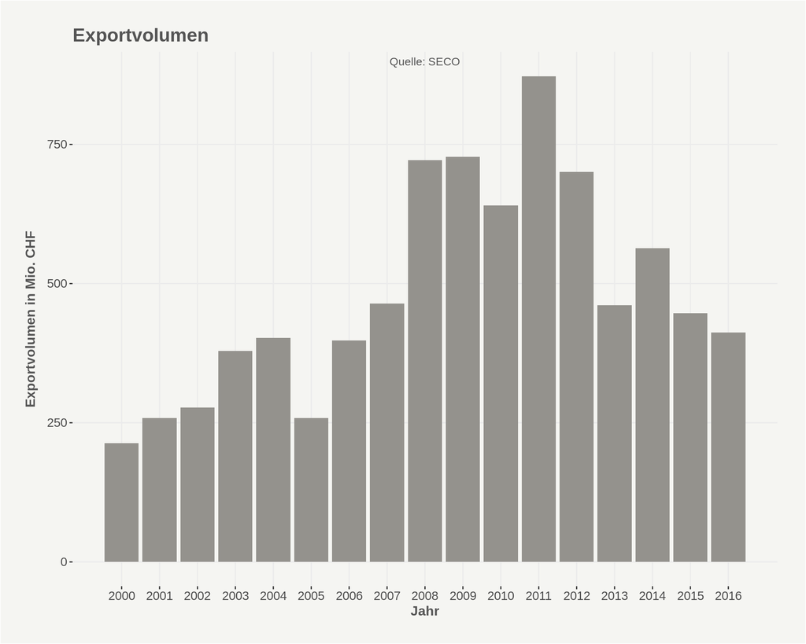

```r
# Barplot des Gesamtvolumens nach Jahr
volmio_1 <- Export$value/1000000 # Exportvolumen in Millionen
ExportBar <- ggplot(data = Export, aes(x = Jahr, y = volmio_1)) +
   geom_bar(stat = "identity", fill = "#94928d") +
   xlab("Jahr") +
   scale_y_continuous(name="Exportvolumen in Mio. CHF", labels=function(x) format(x, big.mark = "'", scientific = FALSE))+
   theme_srf_small()+
   sources_small("SECO", vpos = "top") +
   ggtitle(paste("Exportvolumen")) +
   scale_x_continuous(breaks=seq(2000,2016,1),labels=abs(seq(2000,2016,1))) +
   theme(axis.text.x = element_text(angle=0, vjust=0.5))
ExportBar
```

```r
# speichern der Grafik als png im Ordner output
#png(filename = "output/ExportvolumenNachJahr.png", width = 624, height = 468)
#ExportBar + theme_srf() + sources("SECO", vpos = "top")+theme(axis.text.x = element_text(angle=-30, #vjust=0.5))
#dev.off()
rm(ExportBar, volmio_1)
```

#### Empfängerländer

An wie viele verschiedene Länder hat die Schweiz pro Jahr Kriegsgüter exportiert?

```r
# Berechne Anzahl der belieferten Länder pro Jahr

AnzahlLaender <- list() # leere Zielliste
for(i in 2000:2016){ # Schleife über die Daten aus den Jahren 2000 bis 2014
AnzahlLaender[[i]] <- length(unique(export_restructured[export_restructured$Jahr==i,]$Land)) # Anzahl der Länder werden nach Jahr berechnet und das Ergebnis in der Liste abgelegt
}

Anzahldat <- do.call(rbind.data.frame, AnzahlLaender[2000:2016]) # Anzahlliste zu data frame machen
names(Anzahldat) <- c("Anzahl") # Namen der Anzahlspalte ändern
Anzahldat$Jahr <- 2000:2016 # Zweite Spalte mit Jahreszahlen hinzufügen
Anzahldat # data frame mit Anzahl belieferter Länder pro Jahr
```

```
##    Anzahl Jahr
## 1      57 2000
## 2      66 2001
## 3      59 2002
## 4      65 2003
## 5      59 2004
## 6      72 2005
## 7      62 2006
## 8      66 2007
## 9      72 2008
## 10     74 2009
## 11     69 2010
## 12     68 2011
## 13     68 2012
## 14     71 2013
## 15     72 2014
## 16     71 2015
## 17     70 2016
```

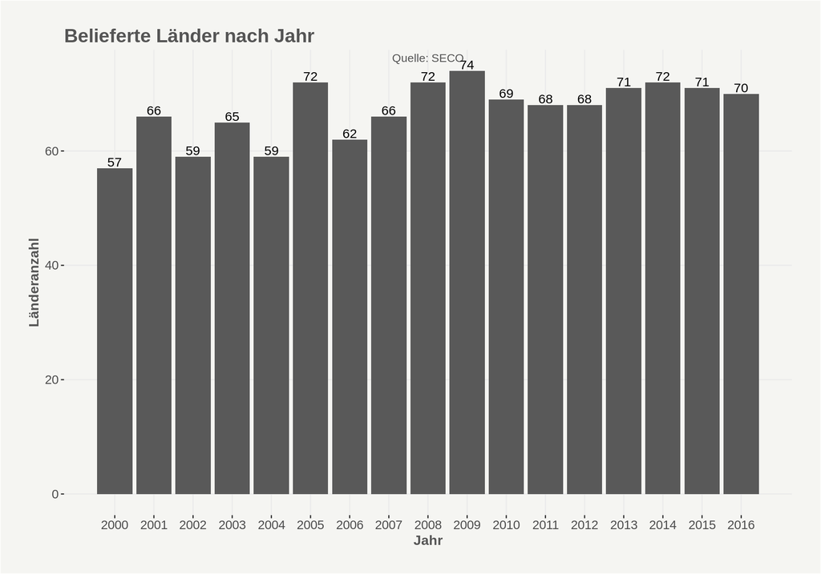

```r
# Barplot der Azahl belieferter Länder nach Jahr
AnzahlLaenderBar <- ggplot(data = Anzahldat, aes(x = Jahr, y = Anzahl)) +
   geom_bar(stat = "identity") +
   xlab("Jahr") +
   scale_y_continuous(name="Länderanzahl")+
   theme_srf_small()+
   sources_small("SECO", vpos = "top") +
   geom_text(aes(label = Anzahl, vjust=-0.2), size = 4)+
   ggtitle(paste("Belieferte Länder nach Jahr")) +
   scale_x_continuous(breaks=seq(2000,2016,1),labels=abs(seq(2000,2016,1))) +
   theme(axis.text.x = element_text(angle=0, vjust=0.5))
AnzahlLaenderBar
```

```r
# speichern der Grafik als png im Ordner output
#png(filename = "output/AnzahlLaender.png", width = 624, height = 468)
#AnzahlLaenderBar + theme_srf()
#dev.off()

# Durchschnitt belieferter Länder pro Jahr
sum(Anzahldat$Anzahl)/length(Anzahldat$Anzahl)
```

```
## [1] 67.11765
```

```r
rm(Anzahldat, laender, AnzahlLaender, AnzahlLaenderBar, i)
```

##### Stammkunden

Welche Länder wurden in jedem Jahr aufs Neue beliefert?

```r
Stammlaender <- list() # leere Zielliste
for(i in 2000:2016){
  Stammlaender[[i]] <- unique(export_restructured[export_restructured$Jahr==i,]$Land) # Länder werden nach Jahren sortiert und in der Liste abgelegt
}

Stamm <- Reduce(intersect, Stammlaender[2000:2016]) # Vektor der Länder, die in jedem Jahr beliefert wurden

length(Stamm) # Anzahl der Länder, die in jedem Jahr unter den Belieferten zu finden sind
```

```
## [1] 27
```

```r
rm(Stamm, Stammlaender)
```

Mit welchen 10 Ländern wird am meisten gehandelt?

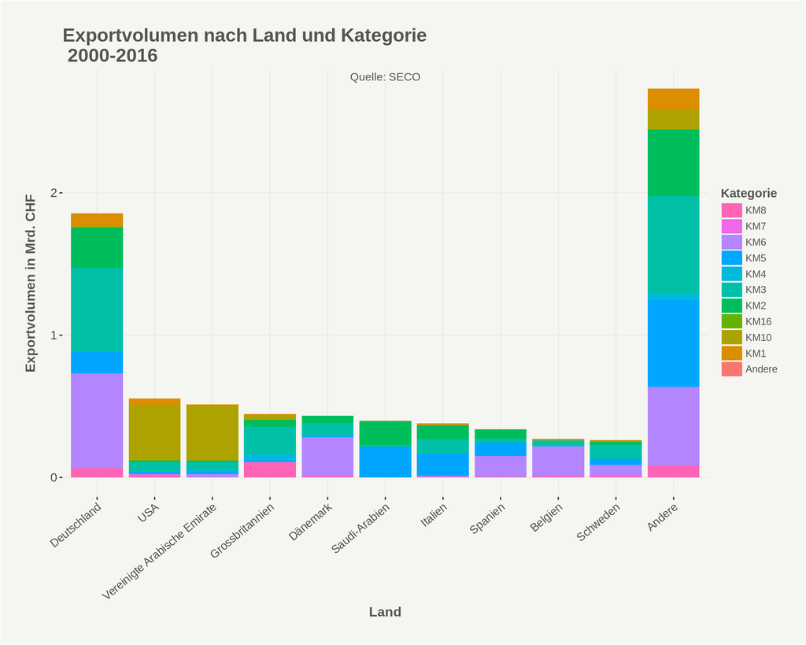

```r
# 2000-2016 gesamt
# erstelle data frame, der nur die zehn Länder mit den höchsten Exportvolumen des Zeitabschnitts enthält

Top10 <- export_restructured %>%
   group_by(Land) %>%
   summarize(value = sum(value)) %>%
   arrange(desc(value)) %>%
   slice(1:10)

# filtere alle Informationen nur dieser zehn Länder aus den Gesamtdaten heraus
 laenderSummen10Sortiert <- export_restructured  %>%
                            filter(Land %in% Top10$Land) %>%
                            group_by(Land, variable) %>% # ordne auch nach Kategorie
                            summarize(value = sum(value)) %>%
                            ungroup()

# definiere eine Funktion, die in filter() als "alles, außer" genutzt werden kann
'%!in%' <- function(x,y)!('%in%'(x,y))

# definiere data frame, der alle anderen Länder enthält
laenderAndere <- export_restructured %>%
                filter(Land %!in% Top10$Land) %>%
                group_by(variable) %>%
                summarize(value = sum(value)) %>%
                arrange(desc(value)) %>%
                select(variable, value) %>%
                ungroup()
laenderAndere$Land <- c("Andere") # benenne die Länder in "Andere" um

# Reihenfolge ändern
laenderAndere <- laenderAndere %>% select(Land, variable, value)

# binde die data frames zu einem
df1 <- laenderSummen10Sortiert[order(match(laenderSummen10Sortiert$Land, Top10$Land)), ]
laenderSummen10SortiertForBar <- rbind(df1,  laenderAndere)

# barplot des Exportvolumens der zehn Länder mit dem größten Exportvolumen für das Zeitintervall sowie der Summe der Exportvolumen aller anderen Länder eingefärbt nach Kategorien
valmio_2 <- laenderSummen10SortiertForBar$value/1000000000 # Exportvolumen in Millionen
laenderSummenBar <- ggplot(data = laenderSummen10SortiertForBar, aes(x = factor(Land, levels=unique(as.character(Land)) ), y = valmio_2, fill = factor(variable), order = variable)) +
   geom_bar(stat = "identity") +
   scale_y_continuous(name="Exportvolumen in Mrd. CHF", labels=function(x) format(x, big.mark = "'", scientific = FALSE))+
   theme_srf_small()+
   sources_small("SECO", vpos = "top") +
   ggtitle("Exportvolumen nach Land und Kategorie\n 2000-2016") +
   theme(axis.text.x = element_text(angle=40, vjust=1, hjust=1, size=10))+
   guides(fill=guide_legend(title="Kategorie", reverse = T))+
   xlab("Land")
laenderSummenBar
```

```r
# speichern der Grafik als png im Ordner output
#png(filename = "output/ExportvolumenNachJahrTop5.png", width = 624, height = 468)
#laenderSummenBar
#dev.off()

# erstelle nach dem gleichen Muster die gleiche Grafik über eine Schleife für jedes Jahr einzeln
Top10_ <- list()
Laendersummen_ <- list()
laenderAndere_ <- list()
laenderSummen10SortiertForBar_ <- list()
plot <- list()

for(i in 2000:2016){
data <- export_restructured[export_restructured$Jahr == i,]

Top10_[[i]] <- data %>%
               group_by(Land) %>%
               summarize(value = sum(value)) %>%
               arrange(desc(value)) %>%
               slice(1:10)

yearsTop10 <- as.data.frame(Top10_[[i]])

Laendersummen_[[i]] <- data %>%
                       dplyr::filter(Land %in% yearsTop10$Land) %>%
                       group_by(Land, variable) %>%
                       summarize(value = sum(value))%>%
                       arrange(desc(value)) %>%
                       slice(1:10) %>%
                       ungroup()

 laenderAndere_[[i]] <- data %>%
                        filter(Land %!in% yearsTop10$Land) %>%
                        group_by(variable) %>%
                        summarize(value = sum(value)) %>%
                        arrange(desc(value)) %>%
                        select(variable, value) %>%
                        ungroup()
laenderAndere_[[i]]$Land <- c("Andere")

# Reihenfolge ändern
laenderAndere_[[i]] <- laenderAndere_[[i]] %>% select(Land, variable, value)

laenderSummen10SortiertForBar_[[i]] <- rbind( Laendersummen_[[i]][order(match( Laendersummen_[[i]]$Land, yearsTop10$Land)), ], laenderAndere_[[i]])

valmio_4 <- laenderSummen10SortiertForBar_[[i]]$value/1000000
plot[[i]] <- ggplot(data = laenderSummen10SortiertForBar_[[i]], aes(x = factor(Land, levels=unique(as.character(Land)) ), y = valmio_4, fill = factor(variable), order = variable)) +
   geom_bar(stat = "identity") +
   scale_y_continuous(name="Exportvolumen in Mio. CHF", labels=function(x) format(x, big.mark = "'", scientific = FALSE))+
   theme_srf_small()+
   sources_small("SECO", vpos = "top") +
   ggtitle(paste("Exportvolumen der Top 10\n", i)) +
   theme(axis.text.x = element_text(angle=40, vjust=1, hjust=1, size=10))+
   guides(fill=guide_legend(title="Kategorie", reverse = T))+
   xlab("Land")
}
# Grafik für:
# 2000
#plot[[2000]]
# 2001
#plot[[2001]]
# 2002
#plot[[2002]]
# 2003
#plot[[2003]]
# 2004
#plot[[2004]]
# 2005
#plot[[2005]]
# 2006
# plot[[2006]]
# 2007
#plot[[2007]]
# 2008
#plot[[2008]]
# 2009
#plot[[2009]]
# 2010
#plot[[2010]]
# 2011
#plot[[2011]]
# 2012
#plot[[2012]]
# 2013
#plot[[2013]]
# 2014
#plot[[2014]]
# 2015
#plot[[2015]]
# 2016
#plot[[2016]]
rm(Top10, df1, laenderAndere, laenderAndere_, laenderSummen10Sortiert, laenderSummen10SortiertForBar, laenderSummen10SortiertForBar_, yearsTop10, data, Laendersummen_, laenderSummenBar, plot, Top10_, valmio_2, valmio_4)
```

Die Top 10 2000-2016 sind vor allem europäische Länder sowie die USA, Saudi-Arabien und die Vereinigten Arabischen Emirate. Mit großem Abstand auf Platz 1 befindet sich Deutschland, das hauptsächlich KM6 (Panzer- und andere Landfahrzeuge) und KM3 (Munition für die in KM 1, 2 oder 12 erfassten Waffen) gekauft hat. Die Emirate und die USA fallen durch ihren überdurchschnittlichen Anteil von KM10 (Bemannte und unbemannte Luftfahrzeuge inkl. entsprechende Triebwerke) auf. 14/17 Mal befindet sich Deutschland auf Platz 1.

Wie viel Prozent des Exportvolumens fallen auf die 5 Länder mit dem grössten Exportvolumen?

```r
# 2000 bis 2016 gesamt
laenderSummen5Sortiert <- export_restructured %>%
   group_by(Land) %>%
   summarize(value = sum(value)) %>%
   arrange(desc(value)) %>%
   slice(1:5)

laenderSummen5Sortiert # betrachte data frame
```

```
## # A tibble: 5 x 2
##                           Land      value
##                          <chr>      <dbl>
## 1                  Deutschland 1857634012
## 2                          USA  556298710
## 3 Vereinigte Arabische Emirate  514566601
## 4              Grossbritannien  446851274
## 5                     Dänemark  435175330
```

```r
# Anteil der Ausfuhren an die fünf Länder mit dem größten Exportvolumen gesamt 2000-2016 am Gesamtexportvolumen
sum(laenderSummen5Sortiert$value)/sum(export_restructured$value) * 100
```

```
## [1] 46.47987
```

```r
# berechne Exportsummen der Top 5 gesamt für jedes Jahr
AnteilTop5 <- list()
 for(i in 2000:2016){
  laenderSummen5proJahr <- export_restructured[export_restructured$Jahr == i,] %>%
   group_by(Land) %>%
   summarize(value = sum(value)) %>%
   arrange(desc(value)) %>%
   slice(1:5)

AnteilTop5[[i]] <-  paste(sum(laenderSummen5proJahr$value)/sum(export_restructured[export_restructured$Jahr == i,]$value) * 100, "%")
 }

# Merge Liste der Ergebnisse zu überscihtlicherem data frame
LAnteilTop5 <- do.call(rbind.data.frame, AnteilTop5[2000:2016])
names(LAnteilTop5) <- c("Anteil") # Namen der Anteilsspalte ändern
LAnteilTop5$Jahr <- 2000:2016 # Zweite Spalte mit Jahreszahlen hinzufügen

LAnteilTop5
```

```
##                Anteil Jahr
## 1  54.2783055072942 % 2000
## 2  58.7467416727784 % 2001
## 3   61.690325592738 % 2002
## 4  62.4467156417566 % 2003
## 5  61.3092261247152 % 2004
## 6  58.7491503045091 % 2005
## 7   66.263094508731 % 2006
## 8  50.8172941468241 % 2007
## 9     55.5721785969 % 2008
## 10 65.4351606880417 % 2009
## 11 61.7405932204278 % 2010
## 12  71.912583188164 % 2011
## 13 71.1855637086115 % 2012
## 14 63.2640132354024 % 2013
## 15 73.3522585948414 % 2014
## 16 60.6324865351501 % 2015
## 17 57.4480651780107 % 2016
```

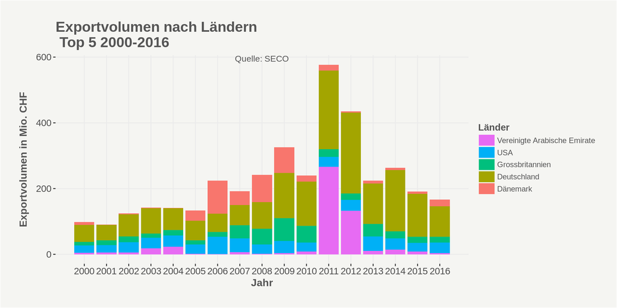

```r
# Barchart: Wie hat sich das Exportvolumen der Top 5 pro Jahr verändert?
# 2000 bis 2016 gesamt
Top5 <- export_restructured  %>%
   filter(Land %in% laenderSummen5Sortiert$Land) %>%
   group_by(Jahr, Land) %>%
   summarize(value = sum(value))

valmio_14 <- Top5$value/1000000
Top5bar <- ggplot(data = Top5, aes(x = Jahr, y = valmio_14, fill = Land)) +
   geom_bar(stat = "identity") +
   scale_y_continuous(name="Exportvolumen in Mio. CHF", labels=function(x) format(x, big.mark = "'", scientific = FALSE))+
   scale_x_continuous(breaks=seq(2000,2016,1),labels=abs(seq(2000,2016,1))) +
   theme_srf_small()+
   sources_small("SECO", vpos = "top") +
   ggtitle("Exportvolumen nach Ländern \n Top 5 2000-2016") +
   guides(fill=guide_legend(title="Länder", reverse = T))+
   xlab("Jahr")
Top5bar
```

```r
# speichern der Grafik als png im Ordner output
#png(filename = "output/Top5nachLandundJahr.png", width = 624, height = 468)
#Top5bar + theme_srf() + sources("SECO", vpos = "top")
#dev.off()
rm(laenderSummen5proJahr, laenderSummen5Sortiert, LAnteilTop5, Top5, AnteilTop5, i, Top5bar, valmio_14, valmio_2)
```

#### KM-Kategorien

Wie verteilt sich das Exportvolumen auf die einzelnen Kategorien?

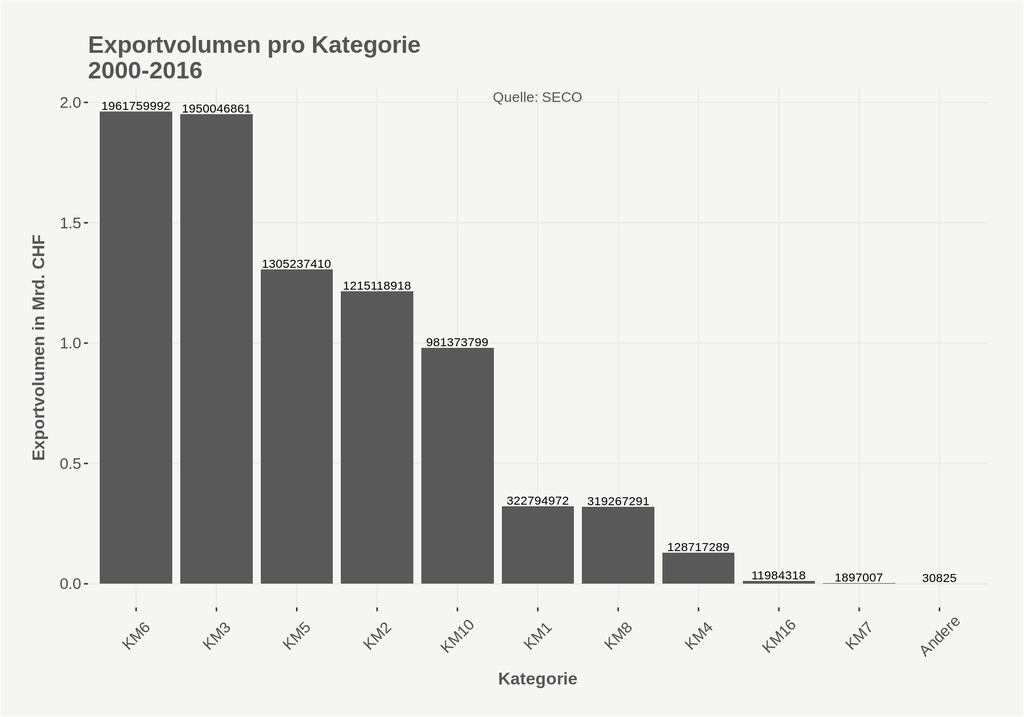

```r
# 2000-2016 gesamt

Kategorie_Summen <- export_restructured  %>%
   group_by(variable) %>%
   summarize(value = sum(value)) %>% # Exportvolumensummen pro Kategorie berechnen
   arrange(desc(value)) %>% # der Größe nach sortieren
   mutate(variable = factor(variable, levels = variable)) # Kategorie in Faktor konvertieren

# Barplot
valmio_5 <- Kategorie_Summen$value/1000000000
Kategorie_SummenBar <- ggplot(data = Kategorie_Summen, aes(x = variable, y = valmio_5)) +
   geom_bar(stat = "identity") +
   geom_text(aes(label = value, vjust=-0.2), size = 3)+
   xlab("Kategorie") +
   scale_y_continuous(name="Exportvolumen in Mrd. CHF", labels=function(x) format(x, big.mark = "'", scientific = FALSE))+
   theme_srf_small()+
   sources_small("SECO", vpos = "top") +
   ggtitle("Exportvolumen pro Kategorie\n2000-2016") +
   theme(axis.text.x = element_text(angle=45, vjust=0.5))
Kategorie_SummenBar
```

```r
# speichern der Grafik als png im Ordner output
#png(filename = "output/VolumenanteilnachKat.png", width = 624, height = 468)
#Kategorie_SummenBar + theme_srf() + sources("SECO", vpos = "top")
#dev.off()

# Anteile der Kategorien an Gesamtvolumen berechnen

gesamt <- sum(Export$value) # Berechnung der Summe aller Exporte 2000-2016

Kategorie_Anteil <- export_restructured  %>%
   group_by(variable) %>%
   summarize(value = (sum(value)/gesamt)*100) %>%
   mutate(variable = factor(variable, levels = variable))

Kategorie_Anteil
```

```
## # A tibble: 11 x 2
##    variable         value
##      <fctr>         <dbl>
##  1   Andere  0.0003759959
##  2      KM1  3.9373745783
##  3     KM10 11.9705589715
##  4     KM16  0.1461817969
##  5      KM2 14.8217250962
##  6      KM3 23.7861974414
##  7      KM4  1.5700621926
##  8      KM5 15.9209685486
##  9      KM6 23.9290713652
## 10      KM7  0.0231392301
## 11      KM8  3.8943447833
```

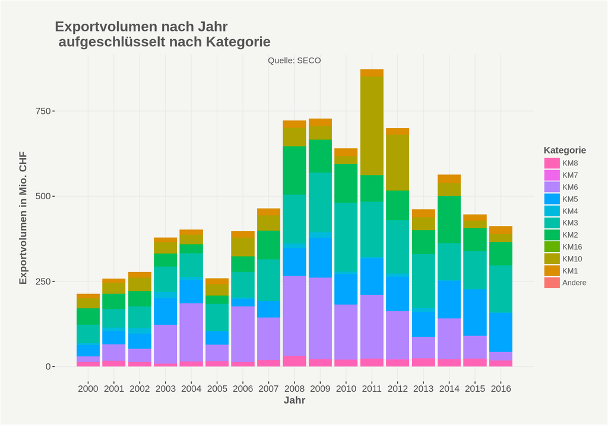

```r
# Anteile der Kategorien nach Jahr
KatexportNachJahr <- export_restructured  %>%
   group_by(Jahr, variable) %>%
   summarize(value = sum(value)) %>%
   mutate(variable = factor(variable))

valmio_6 <- KatexportNachJahr$value/1000000 # Exportvolumen in Millionen
KatexportNachJahrBar <- ggplot(data = KatexportNachJahr, aes(x = Jahr, y = valmio_6, fill = factor(variable), order = variable)) +
  geom_bar(stat = "identity") +
   xlab("Jahr") +
   scale_y_continuous(name="Exportvolumen in Mio. CHF", labels=function(x) format(x, big.mark = "'", scientific = FALSE))+
   theme_srf_small()+
   sources_small("SECO", vpos = "top") +
   ggtitle("Exportvolumen nach Jahr\n aufgeschlüsselt nach Kategorie") +
   guides(fill=guide_legend(title="Kategorie", reverse = T))+
   scale_x_continuous(breaks=seq(2000,2016,1),labels=abs(seq(2000,2016,1))) +
   theme(axis.text.x = element_text(angle=0, vjust=0.5))
KatexportNachJahrBar
```

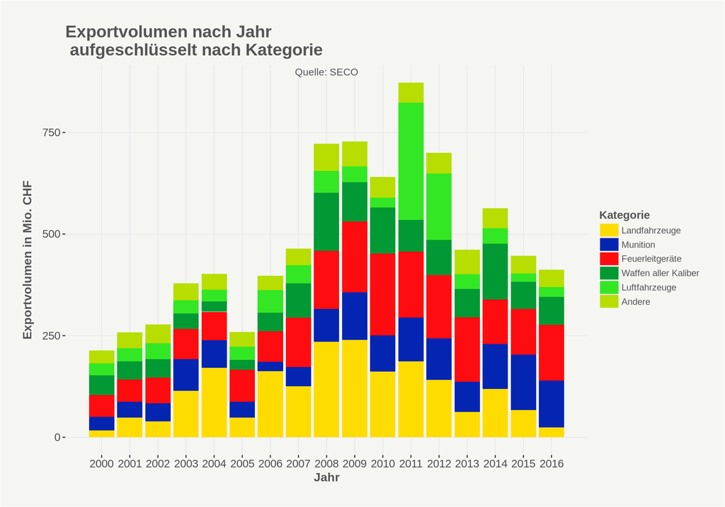

```r
# speichern der Grafik als png im Ordner output
#png(filename = "output/VolumenanteilnachKatproJahr.png", width = 624, height = 468)
#KatexportNachJahrBar + theme_srf() + sources("SECO", vpos = "top")
#dev.off()

####### 5 Top Kat
#nach Jahr
Top5_Kat <- export_restructured  %>%
   group_by(variable) %>%
   summarize(value = sum(value)) %>%
   arrange(desc(value)) %>%
   mutate(variable = factor(variable, levels = variable)) %>%
   slice(1:5)

# benenne alle Kategorien, die nicht unter den Top 5 sind in "Andere" und summiere ihre Exportvolummen
TopKatexportNachJahr <-  KatexportNachJahr %>%
  mutate(variable = ifelse(variable %in% Top5_Kat$variable, as.character(variable), "Andere")) %>%
  group_by(Jahr, variable)%>%
  summarize(value = sum(value))

# Barchart der Anteile der Kategorien am Gesamtexportvolumen nach Jahr, wobei unter "Andere" alle Kategorien zusammengefasst sind, die nicht unter den Top 5 sind
valmio_7 <- TopKatexportNachJahr$value/1000000
TopKatexportNachJahrBar <- ggplot(data = TopKatexportNachJahr, aes(x = Jahr, y = valmio_7, fill = factor(variable))) +
  geom_bar(stat = "identity") +
   xlab("Jahr") +
   scale_y_continuous(name="Exportvolumen in Mio. CHF", labels=function(x) format(x, big.mark = "'", scientific = FALSE))+
   theme_srf_small()+
   sources_small("SECO", vpos = "top") +
   ggtitle("Exportvolumen nach Jahr\n aufgeschlüsselt nach Kategorie") +
   guides(fill=guide_legend(title="Kategorie", reverse = T))+
   scale_x_continuous(breaks=seq(2000,2016,1),labels=abs(seq(2000,2016,1))) +
   theme(axis.text.x = element_text(angle=0, vjust=0.5))+
   scale_fill_manual(labels = rev(c("Landfahrzeuge", "Munition","Feuerleitgeräte", "Waffen aller Kaliber", "Luftfahrzeuge", "Andere")) , # gebe Kategorien für Legende einen Namen
   values = c( # ordne Farben zu
 "KM6" = "#FFDC00",
 "KM3" = "#FF0C10",
 "KM5" = "#0425B2",
 "KM2" = "#009933",
 "KM10"  = "#33E724",
 "Andere" = "#B7DE00"
  ), drop = F)
TopKatexportNachJahrBar
```

```r
# speichern der Grafik als png im Ordner output
#png(filename = "output/TopVolumenanteilnachKatproJahr.png", width = 624, height = 468)
#TopKatexportNachJahrBar + theme_srf() + sources("SECO", vpos = "top")+theme(axis.text.x = #element_text(angle=-30, vjust=0.5))
#dev.off()
rm(Export, Kategorie_Anteil, Kategorie_Summen, KatexportNachJahr, TopKatexportNachJahr, TopKatexportNachJahrBar, gesamt, Kategorie_SummenBar, KatexportNachJahrBar, valmio_5, valmio_6, valmio_7)
```

Insgesamt exportierte die Schweiz im Zeitintervall 2000-2016 KM6 (Panzer- und andere Landfahrzeuge; 2 Milliarden) und KM3 (Munition für die in KM 1, 2 oder 12 erfassten Waffen; 2 Milliarden) am meisten. Starker Anstieg von KM10 (Bemannte und unbemannte Luftfahrzeuge inkl. entsprechende Triebwerke) in den Jahren 2011 und 2012, ab 2008 insgesamt mehr aber vor allem KM6. 2013 wieder ungefähr das gleiche Exportvolumen wie 2007, 2014 wieder mehr.

##### Kategorien über Zeit, Liniencharts

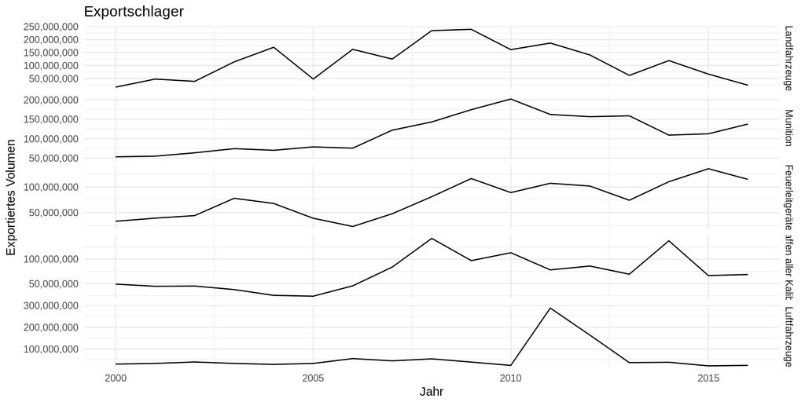

```r
km_names <- list(
  'KM6'="Landfahrzeuge",
  'KM3'="Munition",
  'KM5'="Feuerleitgeräte",
  'KM2'="Waffen aller Kaliber",
  'KM10'="Luftfahrzeuge"
)
km_labeller <- function(variable, value){
 return(km_names[value])
}
data_for_line_plot <- export_restructured %>%
  group_by(Jahr, variable) %>%
  summarize(value = sum(value)) %>%
  ungroup() %>%
  filter(variable %in% Top5_Kat$variable) %>%
  mutate(variable = factor(variable, levels = Top5_Kat$variable))

p <- ggplot(data_for_line_plot, aes(x = Jahr, y = value)) +
  geom_line() +
  facet_grid(variable ~ ., scales = "free_y", labeller = km_labeller) +
  ylab("Exportiertes Volumen") +
  xlab("Jahr") +
  ggtitle("Exportschlager") +
  scale_y_continuous(labels = comma) +
  theme_minimal()
  # ylim(c(0, max(data_to_plot$pop_year)))
p
```

```r
rm(data_for_line_plot, km_names, p, Top5_Kat, km_labeller)
```

##### Nur Naher Osten

```r
# definiere den nahen Osten
neareastcountries <- c("Kuwait", "Bahrain", "Oman", "Katar", "Saudi-Arabien", "Vereinigte Arabische Emirate", "Jemen", "Israel", "Jordanien", "Libanon", "Syrien", "Ägypten", "Iran", "Türkei", "Irak")
```

Summe nach Jahr für den nahen Osten

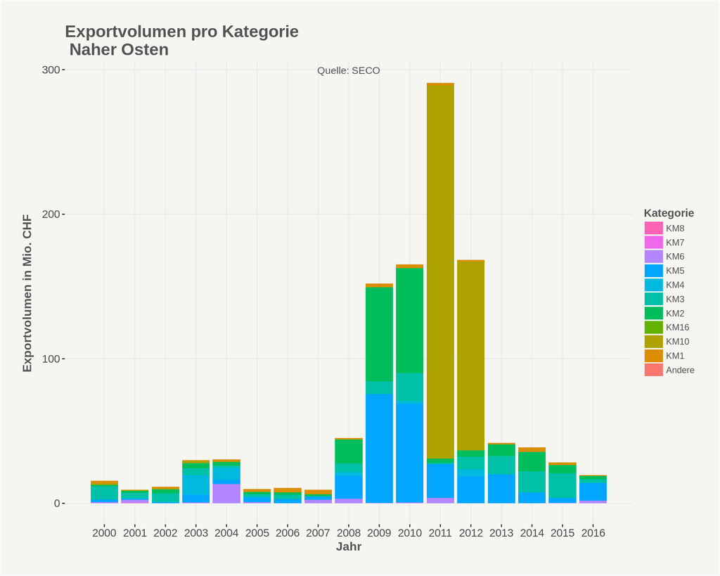

```r
OSTexportvolumenNachJahr <- export_restructured  %>%
   filter(Land %in% neareastcountries) %>%
   group_by(Jahr, variable) %>%
   summarize(value = sum(value))

# Barchart des Exportvolumens pro Jahr und aufgeschlüsselt nach Kategorien für die Länder des Nahen Ostens
valmio_8 <- OSTexportvolumenNachJahr$value/1000000
OSTexportvolumenNachJahrBar <- ggplot(data = OSTexportvolumenNachJahr, aes(x = Jahr, y = valmio_8, fill = factor(variable), order = variable)) +
   geom_bar(stat = "identity") +
   scale_y_continuous(name="Exportvolumen in Mio. CHF", labels=function(x) format(x, big.mark = "'", scientific = FALSE))+
   scale_x_continuous(breaks=seq(2000,2016,1),labels=abs(seq(2000,2016,1))) +
   theme_srf_small()+
   sources_small("SECO", vpos = "top") +
   ggtitle("Exportvolumen pro Kategorie \n Naher Osten") +
   guides(fill=guide_legend(title="Kategorie", reverse = T))+
   xlab("Jahr")
OSTexportvolumenNachJahrBar
```

```r
# speichern der Grafik als png im Ordner output
#png(filename = "output/OstnachJahr.png", width = 624, height = 468)
#OSTexportvolumenNachJahrBar + theme_srf() + sources("SECO", vpos = "top")
#dev.off()
rm(OSTexportvolumenNachJahrBar, valmio_5, valmio_6, valmio_7, valmio_8)
```

#### Auswertungen Naher Osten

Wie viel Prozent des Exportvolumens fällt auf den Nahen Osten?

```r
# 2000 bis 2016 gesamt
sum(OSTexportvolumenNachJahr$value) #Summe Exportvolumen an den Nahen Osten 2000-2016
```

```
## [1] 1076863433
```

```r
sum(OSTexportvolumenNachJahr$value)/sum(export_restructured$value) * 100 #Anteil in Prozent
```

```
## [1] 13.13532
```

```r
# für jedes Jahr
AnteilOST <- list()
 for(i in 2000:2016){
AnteilOST[[i]] <- sum(OSTexportvolumenNachJahr[OSTexportvolumenNachJahr$Jahr == i,]$value)/sum(export_restructured[export_restructured$Jahr == i,]$value) * 100
 }

# Ergebnisse zu übersichtlichem data frame mergen
LAnteilOST <- do.call(rbind.data.frame, AnteilOST[2000:2016])
names(LAnteilOST) <- c("Anteil") # Namen der Anteilsspalte ändern
LAnteilOST$Jahr <- 2000:2016 # Zweite Spalte mit Jahreszahlen hinzufügen

LAnteilOST
```

```
##       Anteil Jahr
## 1   7.320068 2000
## 2   3.672251 2001
## 3   4.118527 2002
## 4   7.866063 2003
## 5   7.549829 2004
## 6   3.797652 2005
## 7   2.663804 2006
## 8   2.014795 2007
## 9   6.257345 2008
## 10 20.903258 2009
## 11 25.803648 2010
## 12 33.328740 2011
## 13 24.034175 2012
## 14  9.087473 2013
## 15  6.883970 2014
## 16  6.362976 2015
## 17  4.724283 2016
```

```r
sum(LAnteilOST[1:9, 1])/length(LAnteilOST[1:9, 1]) # durchschnittlicher Anteil 2000-2008
```

```
## [1] 5.028926
```

```r
sum(LAnteilOST[10:13, 1])/length(LAnteilOST[10:13, 1]) # durchschnittlicher Anteil 2009-2012
```

```
## [1] 26.01746
```

```r
sum(LAnteilOST[14:16, 1])/length(LAnteilOST[14:16, 1]) # durchschnittlicher Anteil 2013-2016
```

```
## [1] 7.444806
```

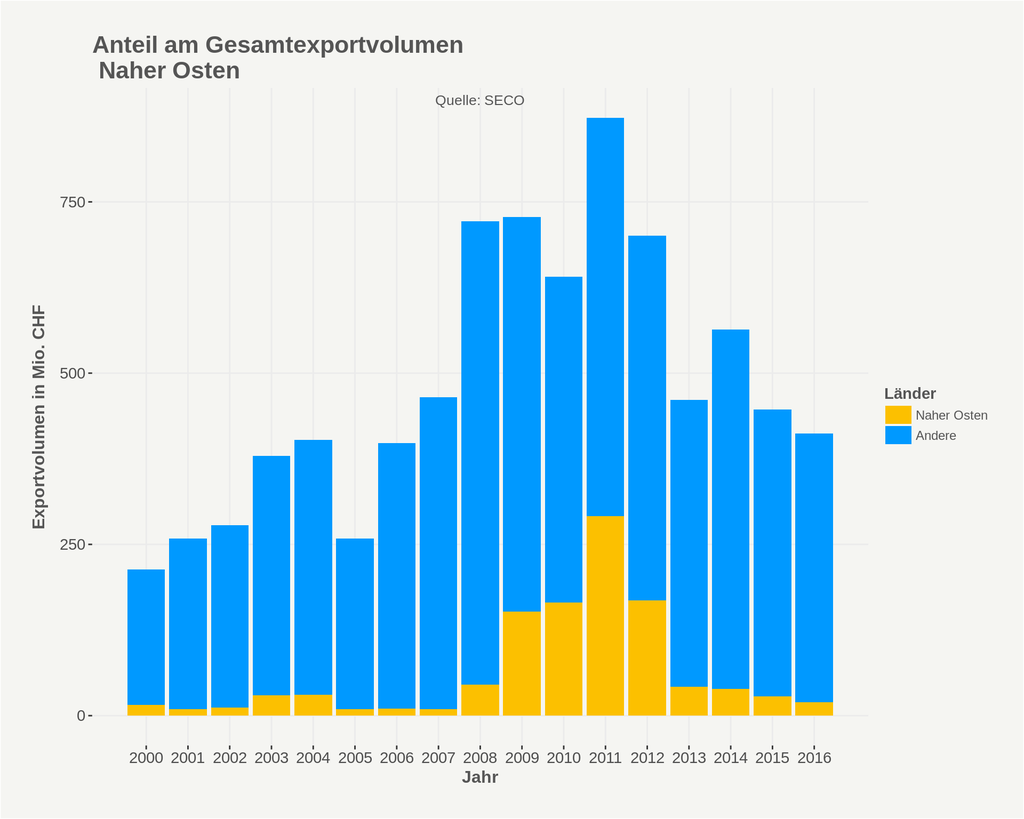

```r
# Exportvolumen des Nahen Ostens in Vergelich zum Gesamtexportvolumen setzen
# Summe der Exportvolumen des Nahen Ostens gesamt pro Jahr
ExportOST <- export_restructured  %>%
   filter(Land %in% neareastcountries) %>%
   group_by(Jahr) %>%
   summarize(value = sum(value))
ExportOST$Länder <- c("Naher Osten")

# alle Länder, die nicht zum Nahen Osten gehören, unter "Andere" zusammenfassen und ihre Summe der Exportvolumen pro Jahr berechnen
ExportGesoOst <- export_restructured  %>%
   filter(Land %!in% neareastcountries) %>%
   group_by(Jahr) %>%
   summarize(value = sum(value))
ExportGesoOst$Länder <- c("Andere")

# beide Datensätze zusammenführen
ExportanteilOstforBar <- rbind(ExportGesoOst, ExportOST)

# barplot des Anteils am Gesamtexportvolumen des Nahen Ostens
valmio_10 <- ExportanteilOstforBar$value/1000000
ExportanteilOstBar <- ggplot(data = ExportanteilOstforBar, aes(x = Jahr, y = valmio_10, fill = factor(Länder))) +
   geom_bar(stat = "identity") +
   scale_y_continuous(name="Exportvolumen in Mio. CHF", labels=function(x) format(x, big.mark = "'", scientific = FALSE))+
   scale_x_continuous(breaks=seq(2000,2016,1),labels=abs(seq(2000,2016,1))) +
   theme_srf_small()+
   sources_small("SECO", vpos = "top") +
   ggtitle("Anteil am Gesamtexportvolumen \n Naher Osten") +
   guides(fill=guide_legend(title="Länder", reverse = T))+
   xlab("Jahr")+
   scale_fill_manual(values = c("#0099ff","#fcc000"))
ExportanteilOstBar
```

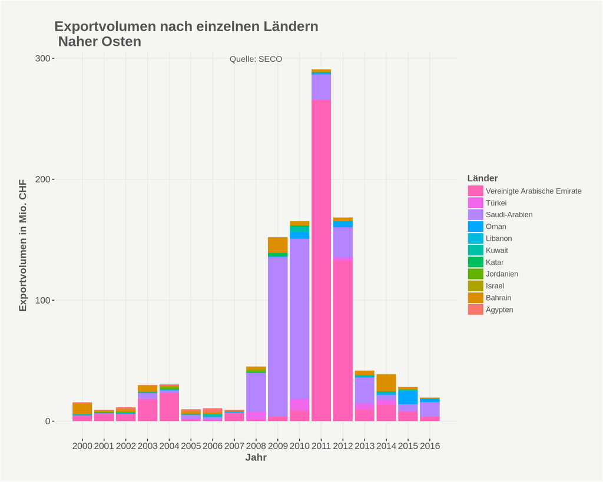

```r
# speichern der Grafik als png im Ordner output
#png(filename = "output/OstanteilanGesamtnachJahr.png", width = 624, height = 468)
#ExportanteilOstBar + theme_srf() + sources("SECO", vpos = "top")+theme(axis.text.x = #element_text(angle=-30, vjust=0.5))
#dev.off()


#Wie hat sich das Exportverhalten der Länder des Nahen Osten pro Jahr verändert?
OST <- export_restructured  %>%
   filter(Land %in% neareastcountries) %>%
   group_by(Jahr, Land) %>%
   summarize(value = sum(value))

valmio_11 <- OST$value/1000000
OSTbar <- ggplot(data = OST, aes(x = Jahr, y = valmio_11, fill = Land)) +
   geom_bar(stat = "identity")+
   scale_y_continuous(name="Exportvolumen in Mio. CHF", labels=function(x) format(x, big.mark = "'", scientific = FALSE))+
   scale_x_continuous(breaks=seq(2000,2016,1),labels=abs(seq(2000,2016,1))) +
   theme_srf_small()+
   sources_small("SECO", vpos = "top") +
   ggtitle(paste("Exportvolumen nach einzelnen Ländern \n Naher Osten")) +
   guides(fill=guide_legend(title="Länder", reverse = T))+
   xlab("Jahr")
OSTbar
```

```r
# speichern der Grafik als png im Ordner output
#png(filename = "output/OstnachLandundJahr.png", width = 624, height = 468)
#OSTbar + theme_srf() + sources("SECO", vpos = "top")
#dev.off()

## wie viel Prozent des Exportvolumens an den nahen Osten fällt allein auf die Emirates und Saudi-Arabien?
EmSau <- c("Vereinigte Arabische Emirate", "Saudi-Arabien")

  EmSauSumm <- export_restructured  %>%
   filter(Land %in% EmSau) %>%
   group_by(Jahr) %>%
   summarize(value = sum(value))

sum(EmSauSumm$value)/sum(OST$value)*100
```

```
## [1] 84.88991
```

```r
rm(EmSauSumm, EmSau, ExportGesoOst, ExportanteilOstBar, ExportanteilOstforBar, ExportOST, OST, LAnteilOST, i, OSTexportvolumenNachJahr, AnteilOST, OSTbar, valmio_10, valmio_11, neareastcountries)
```

#### Nach Kontinenten

Wie verteilt sich das Exportvolumen auf die Kontinente?

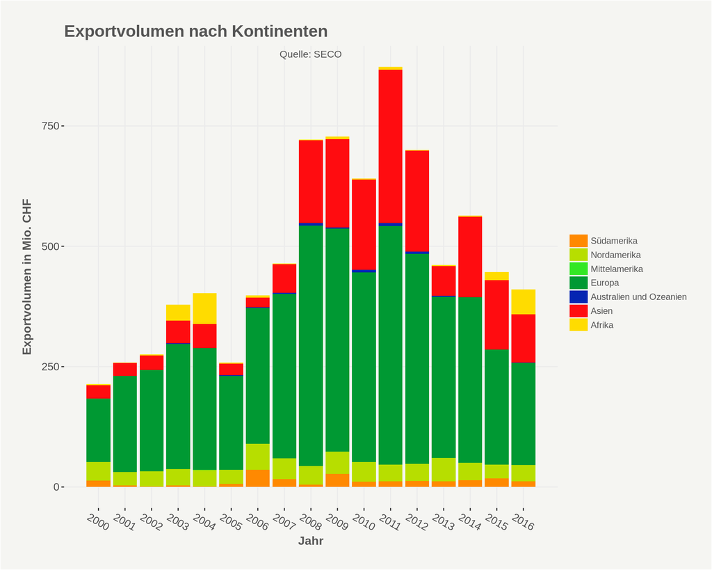

```r
# Reinladen des Excelfiles, das in jeder Spalte die Ländernamen eines anderen Kontinenten beinhaltet
kontinente <- read_excel("input/kontinente.xlsx")

### noch vereinfachen?
  Europa <- export_restructured %>%
   filter(Land %in% kontinente$Europa) %>%
   group_by(Jahr) %>%
   summarize(value = sum(value))

  Asien <- export_restructured %>%
   filter(Land %in% kontinente$Asien) %>%
   group_by(Jahr) %>%
   summarize(value = sum(value))

  Mittelamerika <- export_restructured %>%
   filter(Land %in% kontinente$Mittelamerika) %>%
   group_by(Jahr) %>%
   summarize(value = sum(value))

  Afrika <- export_restructured %>%
   filter(Land %in% kontinente$Afrika) %>%
   group_by(Jahr) %>%
   summarize(value = sum(value))

  Nordamerika <- export_restructured %>%
   filter(Land %in% kontinente$Nordamerika) %>%
   group_by(Jahr) %>%
   summarize(value = sum(value))

  Südamerika <- export_restructured %>%
   filter(Land %in% kontinente$Südamerika) %>%
   group_by(Jahr) %>%
   summarize(value = sum(value))

  AustralienOzeanien <- export_restructured %>%
   filter(Land %in% kontinente$AustralienOzeanien) %>%
   group_by(Jahr) %>%
   summarize(value = sum(value))

regions <- melt(list("Europa" = Europa, "Asien" = Asien, "Mittelamerika" = Mittelamerika,
                     "Afrika" = Afrika, "Nordamerika" = Nordamerika, "Südamerika" = Südamerika,
                     "Australien und Ozeanien" = AustralienOzeanien), id.vars = "Jahr")

valmio_13 <- regions$value/1000000
regionvergleich <- ggplot(data = regions, aes(x = Jahr, y = valmio_13, fill = as.factor(L1), order = L1)) +
   geom_bar(stat = "identity") +
   scale_y_continuous(name="Exportvolumen in Mio. CHF", labels=function(x) format(x, big.mark = "'", scientific = FALSE))+
   scale_x_continuous(breaks=seq(2000,2016,1),labels=abs(seq(2000,2016,1))) +
   theme_srf_small()+
   sources_small("SECO", vpos = "top") +
   ggtitle("Exportvolumen nach Kontinenten") +
   guides(fill=guide_legend(title="", reverse = T))+
   xlab("Jahr")+
    scale_fill_manual(values = c(
    "Australien und Ozeanien" = "#0425B2",
    "Südamerika" = "#FF8901",
    "Nordamerika" = "#B7DE00",
    "Mittelamerika"  = "#33E724",
    "Afrika" = "#FFDC00",
    "Asien" = "#FF0C10",
    "Europa" = "#009933"
  ), drop = F)+
  theme(axis.text.x = element_text(angle=-30, vjust=0.5))
regionvergleich
```

```r
# speichern der Grafik als png im Ordner output
#png(filename = "output/VolumennachKontinenten.png", width = 624, height = 468)
#regionvergleich + theme_srf() + sources("SECO", vpos = "top")+theme(axis.text.x = element_text(angle=-30, #vjust=0.5))
#dev.off()
rm(Afrika, Asien, AustralienOzeanien, Europa, Nordamerika, Mittelamerika, regions, Südamerika, kontinente, valmio_13, regionvergleich)
```

Den grössten Anteil am Exportvolumen nehmen europäische Länder ein. Um 2011 herum nehmen Ausfuhren an asiatische Länder zu. Der Rückgang des Exportvolumens von 2015 an ist u.a. dem Rückgang von Auslieferungen an Europa geschuldet. Die Anteile von Asien 2014 bis 2016 dürften zum Grossteil an Indien und Indonesien sowie Pakistan gehen.